# Spatio-temporal Modelling, Lab 5, 2022-11-30

# 1 Spatial modelling: introductory matter

## 1.1 meuse

The meuse data set is a data set collected from the Meuse floodplain. The heavy metals analyzed are copper, cadmium, lead and zinc concentrations, extracted from the topsoil of a part of the Meuse floodplain, the area around Meers and Maasband (Limburg, The Netherlands). The data were collected during fieldwork in 1990 (Rikken and Rijn 1993; Burrough and McDonnell 1998). Let´s have a look at the data. If not done yet, download the data set from learnweb. The code below assumes the data to sit in subdirectory `data` of your working directory. Adapt the path to wherever you have stored the data on your disk.

```r
library(gstat)
library(sp)
library(rgdal)
meuse <- readOGR("./data/meuse.gpkg")
summary(meuse)
```

```
Object of class SpatialPointsDataFrame
Coordinates:
             min    max
coords.x1 178605 181390
coords.x2 329714 333611
Is projected: TRUE
proj4string :
[+proj=sterea +lat_0=52.1561605555556 +lon_0=5.38763888888889
+k=0.9999079 +x_0=155000 +y_0=463000 +ellps=bessel +units=m +no_defs]
Number of points: 155
Data attributes:
    cadmium           copper            lead            zinc
 Min.   : 0.200   Min.   : 14.00   Min.   : 37.0   Min.   : 113.0
 1st Qu.: 0.800   1st Qu.: 23.00   1st Qu.: 72.5   1st Qu.: 198.0
 Median : 2.100   Median : 31.00   Median :123.0   Median : 326.0
 Mean   : 3.246   Mean   : 40.32   Mean   :153.4   Mean   : 469.7
 3rd Qu.: 3.850   3rd Qu.: 49.50   3rd Qu.:207.0   3rd Qu.: 674.5
 Max.   :18.100   Max.   :128.00   Max.   :654.0   Max.   :1839.0

      elev             dist               om            ffreq
 Min.   : 5.180   Min.   :0.00000   Min.   : 1.000   Length:155
 1st Qu.: 7.546   1st Qu.:0.07569   1st Qu.: 5.300   Class :character
 Median : 8.180   Median :0.21184   Median : 6.900   Mode  :character
 Mean   : 8.165   Mean   :0.24002   Mean   : 7.478
 3rd Qu.: 8.955   3rd Qu.:0.36407   3rd Qu.: 9.000
 Max.   :10.520   Max.   :0.88039   Max.   :17.000
                                    NA's   :2
     soil               lime             landuse              dist.m
 Length:155         Length:155         Length:155         Min.   :  10.0
 Class :character   Class :character   Class :character   1st Qu.:  80.0
 Mode  :character   Mode  :character   Mode  :character   Median : 270.0
                                                          Mean   : 290.3
                                                          3rd Qu.: 450.0
                                                          Max.   :1000.0

      id
 Length:155
 Class :character
 Mode  :character
```

```r
objects()
```

```
[1] "meuse"
```

## 1.2 Models: the formula interface; linear regression

Most statisticians (and many earth scientists as well) like to analyse data through models: models reflect the hypotheses we entertain, and from fitting models, analysing model output, and analysing graphs of fitted values and residuals we can learn from the data whether a given hypothesis was reasonable or not.

Many models are variations of regression models. Here, we will illustrate an example of a simple linear regression model involving the heavy metal pollution data in `meuse`. We will entertain the hypothesis that zinc concentration, present in variable `zinc`, depends linearly on distance to the river, present in `dist`. We can express dependency of y on x by a formula, coded as `y~x`. Formulas can have multiple right-hand sides for multiple linear regression, as `y~x1+x2`; they also can contain expressions (transformations) of variables, as in `log(y)~sqrt(x)`. See `?formula` for a full description of the full functionality.

To calculate a linear regression model for the meuse data:

```r
zinc.lm = lm(zinc ~ dist, meuse)
class(zinc.lm)
```

```
[1] "lm"
```

```r
summary(zinc.lm)
```

```
Call:
lm(formula = zinc ~ dist, data = meuse)

Residuals:
    Min      1Q  Median      3Q     Max
-475.20 -189.94  -52.94  120.15 1088.80

Coefficients:
            Estimate Std. Error t value Pr(>|t|)
(Intercept)   756.70      35.66   21.22   <2e-16 ***
dist        -1195.67     114.84  -10.41   <2e-16 ***
---
Signif. codes:  0 '***' 0.001 '**' 0.01 '*' 0.05 '.' 0.1 ' ' 1

Residual standard error: 281.7 on 153 degrees of freedom
Multiple R-squared:  0.4147,    Adjusted R-squared:  0.4109
F-statistic: 108.4 on 1 and 153 DF,  p-value: < 2.2e-16
```

Do the following yourself:

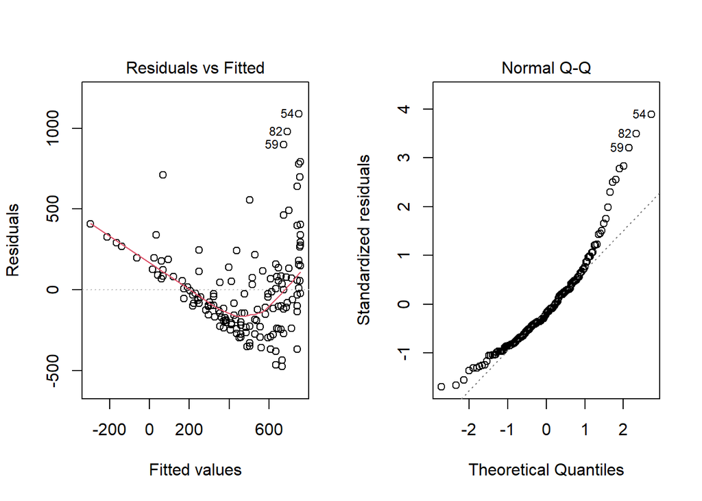

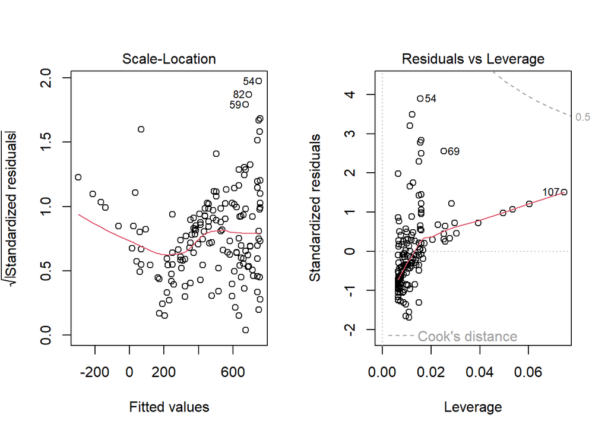

```r
par(mfrow=c(1,2)) #to get two plots in one row
plot(zinc.lm)
```

Besides the variety of plots you now obtain, there are many further custom options you can set that can help analysing these data. When you ask help by `?plot`, it does not provide very helpful information. To get help on the plot method that is called when plotting an object of class `lm`, remember that the function called is `plot.lm`. Read the help of `plot.lm` by `?plot.lm` . You can customize the plot call, e.g. by

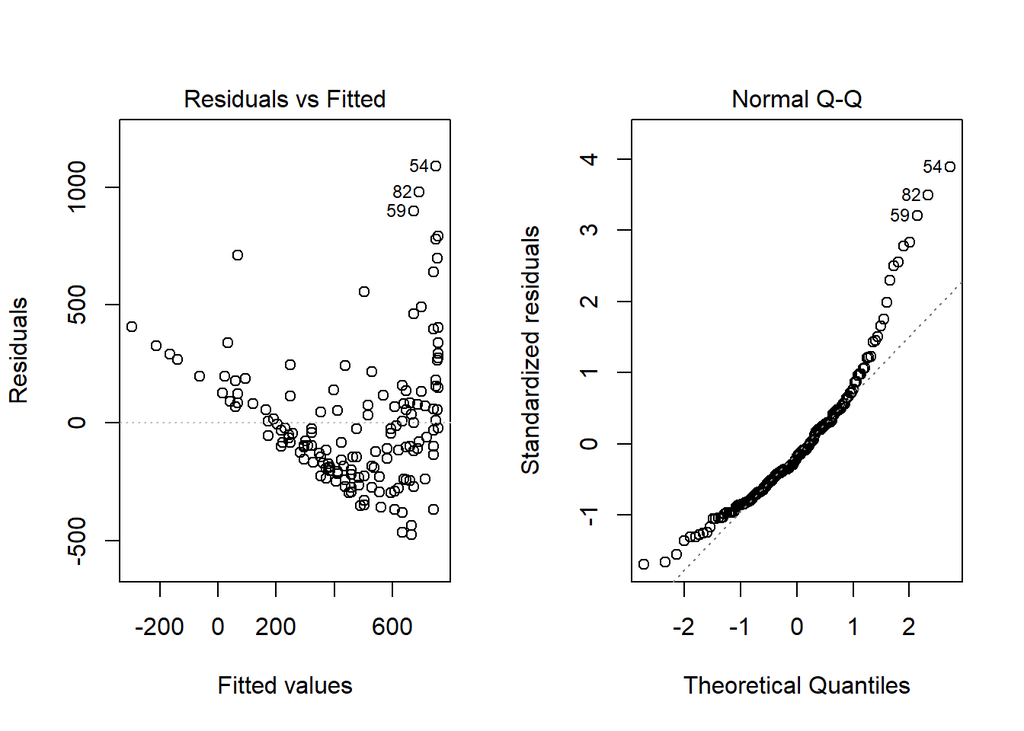

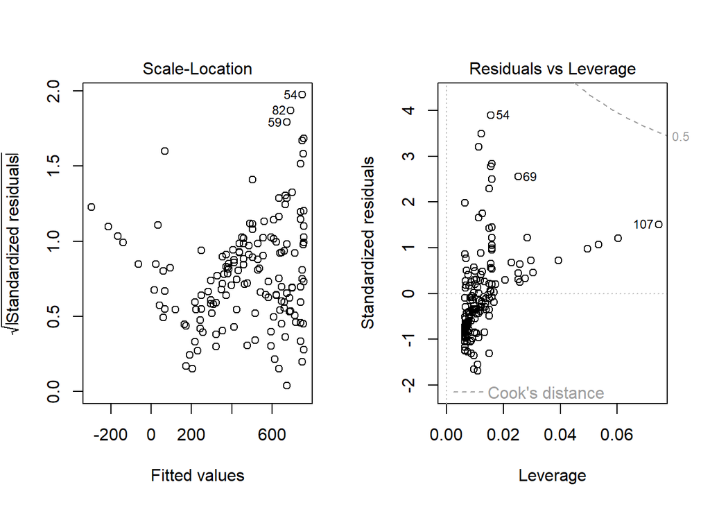

```r
par(mfrow=c(1,2))
plot(zinc.lm, add.smooth = FALSE)
```

In this call, the name of the second function argument is added because the argument panel is in a very rear position. Adding the `FALSE` as a positional argument, as in

```r
par(mfrow=c(1,2))
 plot(zinc.lm, , , , , , , FALSE)
```

will not work as it comes after the `...` argument, which may contain an arbitrary number of arguments that are passed to underlying plot routines. But the following two commands (search for the difference!) both work:

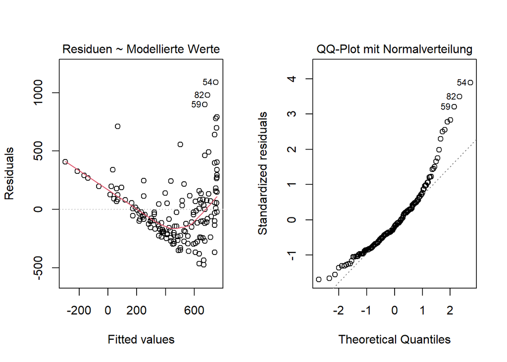

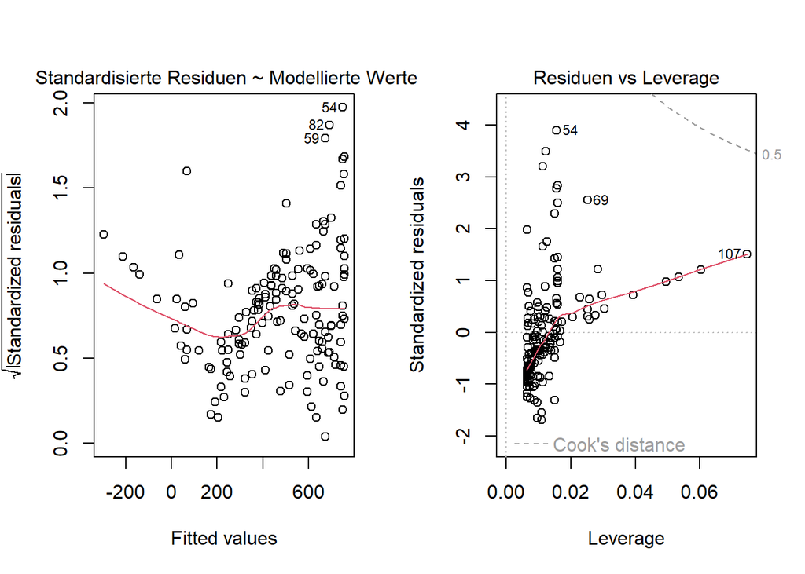

```r
 par(mfrow=c(1,2))
plot(zinc.lm, caption = c("Residuen ~ Modellierte Werte", "QQ-Plot mit Normalverteilung",
    " Standardisierte Residuen ~ Modellierte Werte", "Cook's Distanz", "Residuen vs Leverage",
    "Cook's Distanz vs Leverage"))
```

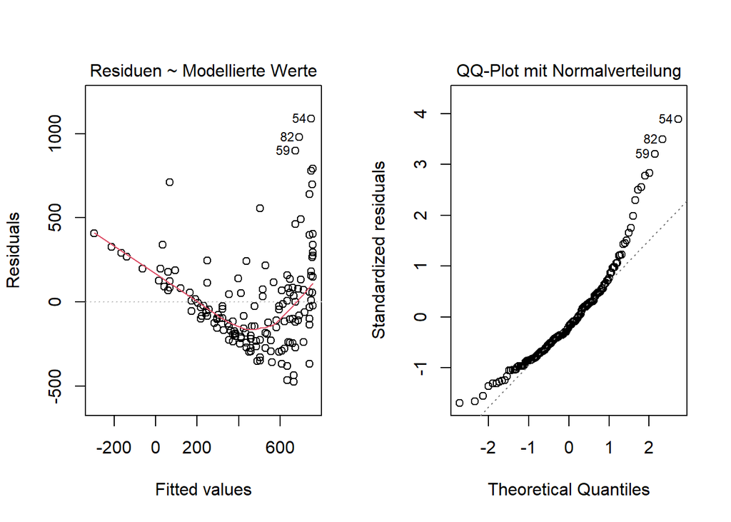

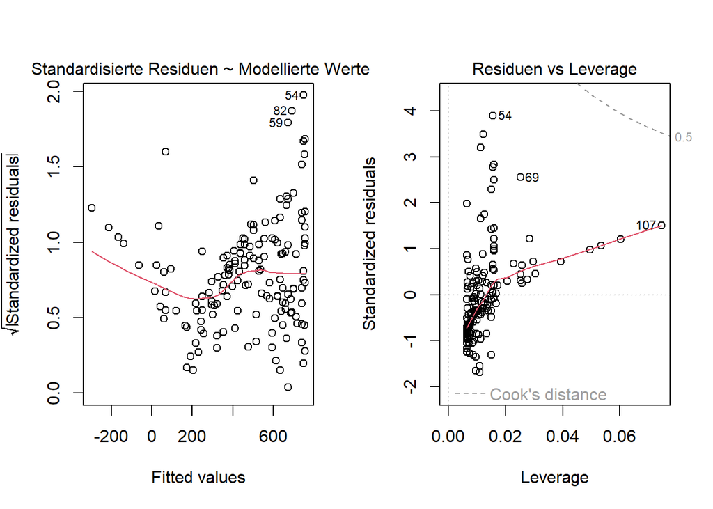

```r
par(mfrow=c(1,2))
plot(zinc.lm, , c("Residuen ~ Modellierte Werte", "QQ-Plot mit Normalverteilung",
    " Standardisierte Residuen ~ Modellierte Werte", "Cook's Distanz", "Residuen vs Leverage",
    "Cook's Distanz vs Leverage"))
```

#### *Exercise 1*

**Exercise 1**

*For this regression model, which of the following violated assumptions underlying linear regression are true (if any):*

1. none
2. residuals are heteroscedastic (i.e., their variance is not constant over the range of fitted values)
3. residuals are not normally distributed (their distribution is for example non-symmetric)
4. residuals are heteroscedastic and not normally distributed

*and explain how you can tell that this is the case.*

**Solution**

The correct answer is d).In the third plot (standardised residuals ~ fitted values) you can see that the residuals are heteroscedastic, i.e. their variance is not constant. In the second plot (QQ-Plot), you can see that the residuals are not normally distributed.

The example above is a spatial model only to the extent that the explanatory variable `dist` in this case contains some spatial information (distance to the river). We are not using the spatial information contained in the `SpatialPointsDataFrame` with respect to the location (coordinates) of the heavy metal measurements. In the following, we will look at actual spatial data analysis starting with how to handle spatial data in R.

## 1.3 Spatial data in R (I): the sp package

The R package **sp** (Pebesma and Bivand 2022a) provides classes and methods for spatial data; currently it can deal with points, grids, lines and polygons. It further provides interfaces to various GIS functions such as overlay, projection and reading and writing of external GIS formats.

### 1.3.1 Points

Try:

```r
class(meuse)
```

```
[1] "SpatialPointsDataFrame"
attr(,"package")
[1] "sp"
```

```r
summary(meuse)
```

```
Object of class SpatialPointsDataFrame
Coordinates:
             min    max
coords.x1 178605 181390
coords.x2 329714 333611
Is projected: TRUE
proj4string :
[+proj=sterea +lat_0=52.1561605555556 +lon_0=5.38763888888889
+k=0.9999079 +x_0=155000 +y_0=463000 +ellps=bessel +units=m +no_defs]
Number of points: 155
Data attributes:
    cadmium           copper            lead            zinc
 Min.   : 0.200   Min.   : 14.00   Min.   : 37.0   Min.   : 113.0
 1st Qu.: 0.800   1st Qu.: 23.00   1st Qu.: 72.5   1st Qu.: 198.0
 Median : 2.100   Median : 31.00   Median :123.0   Median : 326.0
 Mean   : 3.246   Mean   : 40.32   Mean   :153.4   Mean   : 469.7
 3rd Qu.: 3.850   3rd Qu.: 49.50   3rd Qu.:207.0   3rd Qu.: 674.5
 Max.   :18.100   Max.   :128.00   Max.   :654.0   Max.   :1839.0

      elev             dist               om            ffreq
 Min.   : 5.180   Min.   :0.00000   Min.   : 1.000   Length:155
 1st Qu.: 7.546   1st Qu.:0.07569   1st Qu.: 5.300   Class :character
 Median : 8.180   Median :0.21184   Median : 6.900   Mode  :character
 Mean   : 8.165   Mean   :0.24002   Mean   : 7.478
 3rd Qu.: 8.955   3rd Qu.:0.36407   3rd Qu.: 9.000
 Max.   :10.520   Max.   :0.88039   Max.   :17.000
                                    NA's   :2
     soil               lime             landuse              dist.m
 Length:155         Length:155         Length:155         Min.   :  10.0
 Class :character   Class :character   Class :character   1st Qu.:  80.0
 Mode  :character   Mode  :character   Mode  :character   Median : 270.0
                                                          Mean   : 290.3
                                                          3rd Qu.: 450.0
                                                          Max.   :1000.0

      id
 Length:155
 Class :character
 Mode  :character
```

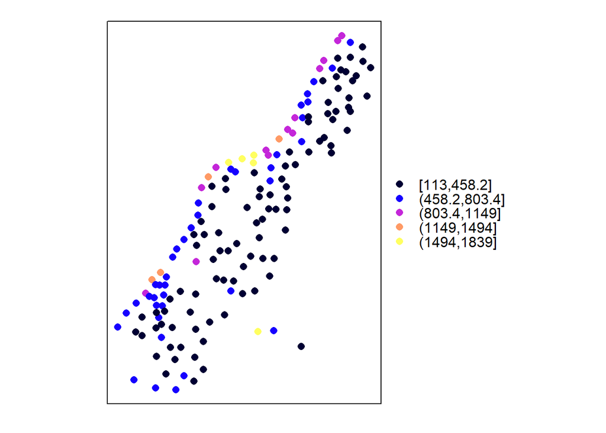

```r
sp.theme(TRUE)
spplot(meuse, "zinc", key.space = "right")
```

The plot now obtained shows points, but without reference where on earth they lie. You could e.g. add a reference by showing the coordinate system:

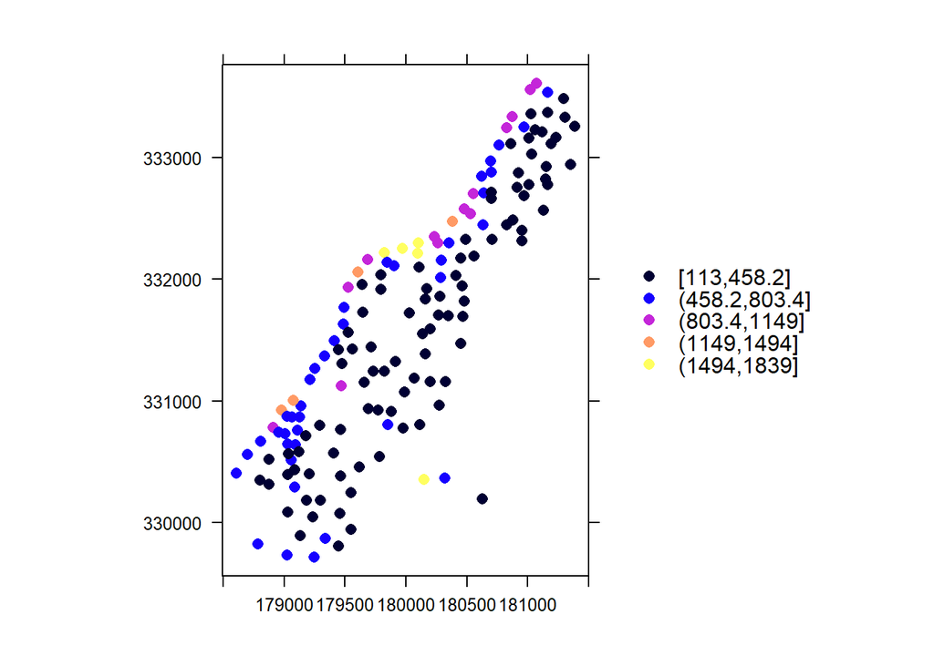

```r
spplot(meuse, "zinc", key.space = "right", scales = list(draw = TRUE))
```

but this tells little about *what* we see. As another option, you can add geographic reference by e.g. lines of rivers, or administrative boundaries. In our example, we prepared a polygon of the Meuse river boundaries, and will add it as reference:

```r
meuse.riv <- readOGR("./data/meuse_river.gpkg")
```

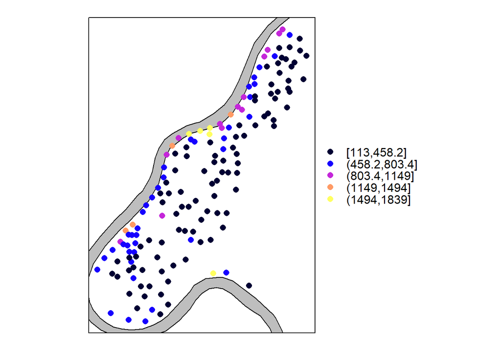

```r
meuse.lt = list("sp.polygons", meuse.riv, fill = "grey")
spplot(meuse, "zinc", key.space = "right", sp.layout = meuse.lt)
```

The `sp.layout` argument contains map elements to be added to an `spplot` plot.

Note that the points in the plot partly fall in the river; this may be attributed to one or more of the following reasons: (i) the river coordinates are not correct, (ii) the point coordinates are not correct, (iii) points were taken on the river bank when the water was low, whereas the river boundary indicates the high water extent of the river.

### 1.3.2 Grids

Try:

```r
library(rgdal)
meuse.grid <- as(readGDAL("./data/meuse_grid.tif"),"SpatialPixelsDataFrame")
```

```
./data/meuse_grid.tif has GDAL driver GTiff
and has 104 rows and 78 columns
```

```r
class(meuse.grid)
```

```
[1] "SpatialPixelsDataFrame"
attr(,"package")
[1] "sp"
```

As you can see, the GeoTiff has been loaded as a `SpatialPixelsDataFrame`. The GeoTiff contains 5 bands: bands 1 and 2 simply indicate, whether a pixel belongs to “part.a” or “part.b” of the study area (“yes” or “no”, i.e., 1 or 0 in the corresponding band). This is an arbitrary division of the area in two parts. Band 3 shows the distance to the river Meuse, band 4 has the soil type, and band 5 indicates the number of times a pixel has been flooded before. To represent this in our `SpatialPixelsDataFrame`, we can assign corresponding names to the data attributes. We will also change the type of the attributes containing categorical data to `factor`.

```r
names(meuse.grid) <- c("part.a","part.b","dist","soil","ffreq")
meuse.grid$soil <- as.factor(meuse.grid$soil)
meuse.grid$ffreq <- as.factor(meuse.grid$ffreq)
```

```r
summary(meuse.grid)
```

```
Object of class SpatialPixelsDataFrame
Coordinates:
     min    max
x 178440 181560
y 329600 333760
Is projected: TRUE
proj4string :
[+proj=sterea +lat_0=52.1561605555556 +lon_0=5.38763888888889
+k=0.9999079 +x_0=155000 +y_0=463000 +ellps=bessel +units=m +no_defs]
Number of points: 3103
Grid attributes:
  cellcentre.offset cellsize cells.dim
x            178460       40        78
y            329620       40       104
Data attributes:
     part.a           part.b            dist        soil     ffreq
 Min.   :0.0000   Min.   :0.0000   Min.   :0.0000   1:1665   1: 779
 1st Qu.:0.0000   1st Qu.:0.0000   1st Qu.:0.1193   2:1084   2:1335
 Median :0.0000   Median :1.0000   Median :0.2715   3: 354   3: 989
 Mean   :0.3986   Mean   :0.6014   Mean   :0.2971
 3rd Qu.:1.0000   3rd Qu.:1.0000   3rd Qu.:0.4402
 Max.   :1.0000   Max.   :1.0000   Max.   :0.9926
```

Let´s try to plot the data:

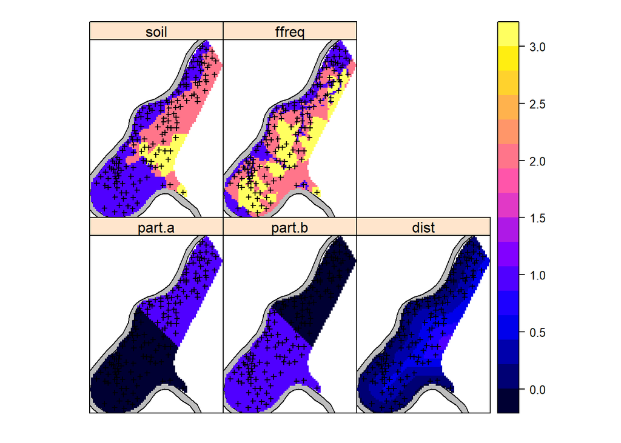

```r
meuse.lt = list(riv = list("sp.polygons", meuse.riv, fill = "grey"), pts = list("sp.points",
    meuse, pch = 3, cex = 0.5, col = "black"))
spplot(meuse.grid, sp.layout = meuse.lt, key.space = "right")
```

For explanation on the `sp.layout` argument, read `?spplot`; much of the codes in them (`pch, cex, col`) are documented in `?par`.

Note that `spplot` plots points on top of the grid, and the grid cells on top of the polygon with the river. (When printing to pdf, transparency options can be used to combine both.)

## 1.4 Import/export: rgdal

R package `rgdal` provides several drivers for import/export of spatial data. We have used it above to read the vector and raster data `meuse`, `meuse.riv` and `meuse.grid`. An overview of available drivers for vector data (points, lines, polygons) can be obtained by

```r
ogrDrivers()
```

```
             name                                            long_name write
1      AmigoCloud                                           AmigoCloud  TRUE
2          ARCGEN                                    Arc/Info Generate FALSE
3          AVCBin                             Arc/Info Binary Coverage FALSE
4          AVCE00                        Arc/Info E00 (ASCII) Coverage FALSE
5             BAG                           Bathymetry Attributed Grid  TRUE
6             CAD                                       AutoCAD Driver FALSE
7           Carto                                                Carto  TRUE
8        Cloudant                                   Cloudant / CouchDB  TRUE
9         CouchDB                                   CouchDB / GeoCouch  TRUE
10            CSV                         Comma Separated Value (.csv)  TRUE
11            CSW               OGC CSW (Catalog  Service for the Web) FALSE
12            DGN                                     Microstation DGN  TRUE
13            DXF                                          AutoCAD DXF  TRUE
14         EDIGEO                        French EDIGEO exchange format FALSE
```

[output cut: 131 more lines]

and for grid data by

```r
gdalDrivers()
```

```
               name                                                long_name
1           AAIGrid                                      Arc/Info ASCII Grid
2              ACE2                                                     ACE2
3              ADRG                            ARC Digitized Raster Graphics
4               AIG                                     Arc/Info Binary Grid
5            AirSAR                                AirSAR Polarimetric Image
6               ARG                                Azavea Raster Grid format
7               BAG                               Bathymetry Attributed Grid
8            BIGGIF                       Graphics Interchange Format (.gif)
9               BLX                                     Magellan topo (.blx)
10              BMP                     MS Windows Device Independent Bitmap
11              BSB                              Maptech BSB Nautical Charts
12               BT                      VTP .bt (Binary Terrain) 1.3 Format
13              BYN                         Natural Resources Canada's Geoid
14              CAD                                           AutoCAD Driver
```

[output cut: 277 more lines]

The full set of theoretically available drivers with documentation are given [here](http://www.gdal.org/formats_list.html) and [here](http://www.gdal.org/ogr_formats.html).

Export the data set to KML

```r
 library(rgdal)
 data(meuse)
 coordinates(meuse) = ~x+y
 proj4string(meuse) = CRS("+init=epsg:28992")
 proj4string(meuse)
 meuse.ll = spTransform(meuse, CRS("+proj=longlat"))
 writeOGR(meuse.ll, "meuse.kml", "meuse.kml", driver="KML")
```

and import it in google earth.

## 1.5 Spatial data in R (II): the packages sf and stars

The package **sf** (Pebesma 2022a), which first appeared on CRAN in 2016, is intended to replace the vector parts of **sp** (among others). It was developed “to move spatial data analysis in R closer to standards-based approaches seen in the industry and open source projects, to build upon more modern versions of the open source geospatial software stack […], and to allow for integration of R spatial software with the tidyverse […]” (Pebesma and Bivand 2022b, chap. 7.1).  
The package **stars** (Pebesma 2022b), which first came to CRAN in 2018, was developed for analyzing raster (and vector) data cubes. It is meant to extend current packages for raster data with functionality to represent dynamic raster stacks (e.g. time series) and to scale computations to data beyond local disc sizes (Pebesma and Bivand 2022b, chap. 7.4).

Both packages are developed to work closely together and can be used for all spatial analyses throughout our exercises. In the following, we show how to repeat the examples from above for handling points and grids with **sf** and **stars**.

### 1.5.1 Points

```r
library(sf)
meuse.sf <- st_read("./data/meuse.gpkg")
```

```r
class(meuse.sf)
```

```
[1] "sf"         "data.frame"
```

```r
summary(meuse.sf)
```

```
    cadmium           copper            lead            zinc
 Min.   : 0.200   Min.   : 14.00   Min.   : 37.0   Min.   : 113.0
 1st Qu.: 0.800   1st Qu.: 23.00   1st Qu.: 72.5   1st Qu.: 198.0
 Median : 2.100   Median : 31.00   Median :123.0   Median : 326.0
 Mean   : 3.246   Mean   : 40.32   Mean   :153.4   Mean   : 469.7
 3rd Qu.: 3.850   3rd Qu.: 49.50   3rd Qu.:207.0   3rd Qu.: 674.5
 Max.   :18.100   Max.   :128.00   Max.   :654.0   Max.   :1839.0

      elev             dist               om            ffreq
 Min.   : 5.180   Min.   :0.00000   Min.   : 1.000   Length:155
 1st Qu.: 7.546   1st Qu.:0.07569   1st Qu.: 5.300   Class :character
 Median : 8.180   Median :0.21184   Median : 6.900   Mode  :character
 Mean   : 8.165   Mean   :0.24002   Mean   : 7.478
 3rd Qu.: 8.955   3rd Qu.:0.36407   3rd Qu.: 9.000
 Max.   :10.520   Max.   :0.88039   Max.   :17.000
                                    NA's   :2
     soil               lime             landuse              dist.m
 Length:155         Length:155         Length:155         Min.   :  10.0
 Class :character   Class :character   Class :character   1st Qu.:  80.0
 Mode  :character   Mode  :character   Mode  :character   Median : 270.0
                                                          Mean   : 290.3
                                                          3rd Qu.: 450.0
                                                          Max.   :1000.0

      id                       geom
 Length:155         POINT        :155
 Class :character   epsg:NA      :  0
 Mode  :character   +proj=ster...:  0
```

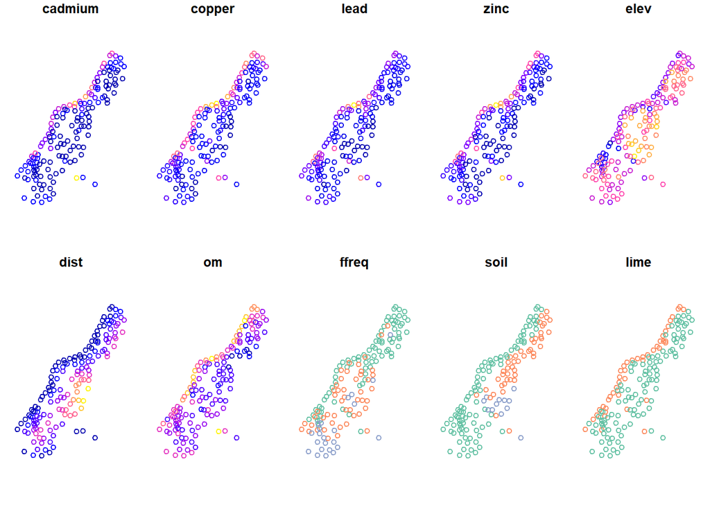

```r
plot(meuse.sf)
```

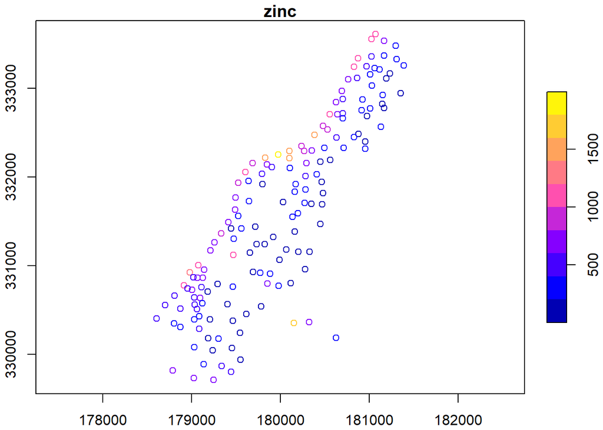

```r
plot(meuse.sf["zinc"],axes=T)
```

Again, we can add the meuse river as refeference.

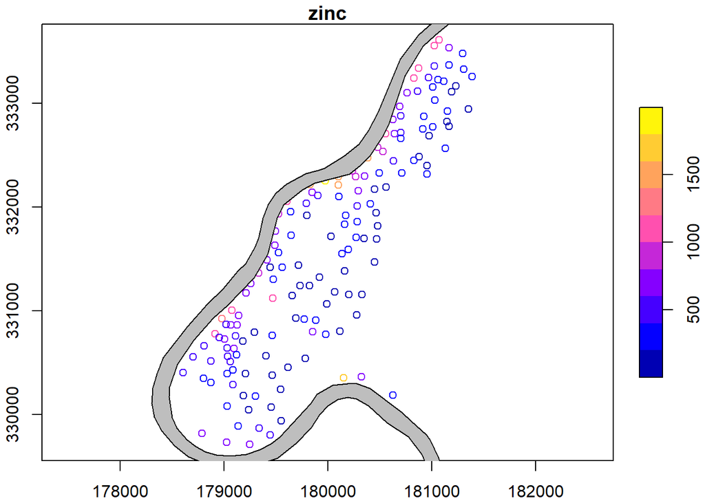

```r
meuse.riv.sf <- st_read("./data/meuse_river.gpkg")
plot(meuse.sf["zinc"],axes=T,reset=F)
plot(meuse.riv.sf,col='grey',add=T)
```

### 1.5.2 Grids

Try:

```r
library(stars)
meuse.grid.stars <- read_stars("./data/meuse_grid.tif")
meuse.grid.stars
```

```
stars object with 3 dimensions and 1 attribute
attribute(s):
                Min.   1st Qu. Median      Mean 3rd Qu. Max.  NA's
meuse_grid.tif     0 0.1192915      1 0.9884603       1    3 25045
dimension(s):
     from  to offset delta              refsys point values x/y
x       1  78 178440    40 Amersfoort / RD New FALSE   NULL [x]
y       1 104 333760   -40 Amersfoort / RD New FALSE   NULL [y]
band    1   5     NA    NA                  NA    NA   NULL
```

The bands of our data set are automatically interpreted as another dimension of the data (here you can recognize the characteristic of **stars** to naturally support multidimensional raster data). However, in this case our bands do not represent another dimension (like for example having the same measurements at different times in the different bands), so instead we want them to be interpreted as 5 different attributes of a 2-dimensional array. This can be done using the function `split`:

```r
meuse.grid.stars <- split(meuse.grid.stars, "band")
meuse.grid.stars
```

```
stars object with 2 dimensions and 5 attributes
attribute(s):
    Min.   1st Qu.   Median      Mean  3rd Qu.     Max. NA's
X1     0 0.0000000 0.000000 0.3986465 1.000000 1.000000 5009
X2     0 0.0000000 1.000000 0.6013535 1.000000 1.000000 5009
X3     0 0.1192915 0.271535 0.2971195 0.440159 0.992607 5009
X4     1 1.0000000 1.000000 1.5775056 2.000000 3.000000 5009
X5     1 1.0000000 2.000000 2.0676764 3.000000 3.000000 5009
dimension(s):
  from  to offset delta              refsys point values x/y
x    1  78 178440    40 Amersfoort / RD New FALSE   NULL [x]
y    1 104 333760   -40 Amersfoort / RD New FALSE   NULL [y]
```

Similar to above, we can now assign the names to the attributes and change the type of the attributes representing categorical variables to `factor`.

```r
names(meuse.grid.stars) <- c("part.a","part.b","dist","soil","ffreq")
meuse.grid.stars$soil <- as.factor(meuse.grid.stars$soil)
meuse.grid.stars$ffreq <- as.factor(meuse.grid.stars$ffreq)
meuse.grid.stars
```

```
stars object with 2 dimensions and 5 attributes
attribute(s):
    part.a          part.b           dist         soil        ffreq
 Min.   :0.000   Min.   :0.000   Min.   :0.000   1   :1665   1   : 779
 1st Qu.:0.000   1st Qu.:0.000   1st Qu.:0.119   2   :1084   2   :1335
 Median :0.000   Median :1.000   Median :0.272   3   : 354   3   : 989
 Mean   :0.399   Mean   :0.601   Mean   :0.297   NA's:5009   NA's:5009
 3rd Qu.:1.000   3rd Qu.:1.000   3rd Qu.:0.440
 Max.   :1.000   Max.   :1.000   Max.   :0.993
 NA's   :5009    NA's   :5009    NA's   :5009
dimension(s):
  from  to offset delta              refsys point values x/y
x    1  78 178440    40 Amersfoort / RD New FALSE   NULL [x]
y    1 104 333760   -40 Amersfoort / RD New FALSE   NULL [y]
```

Let´s try a simple plot before looking more into visualization of `sf` and `stars`objects.

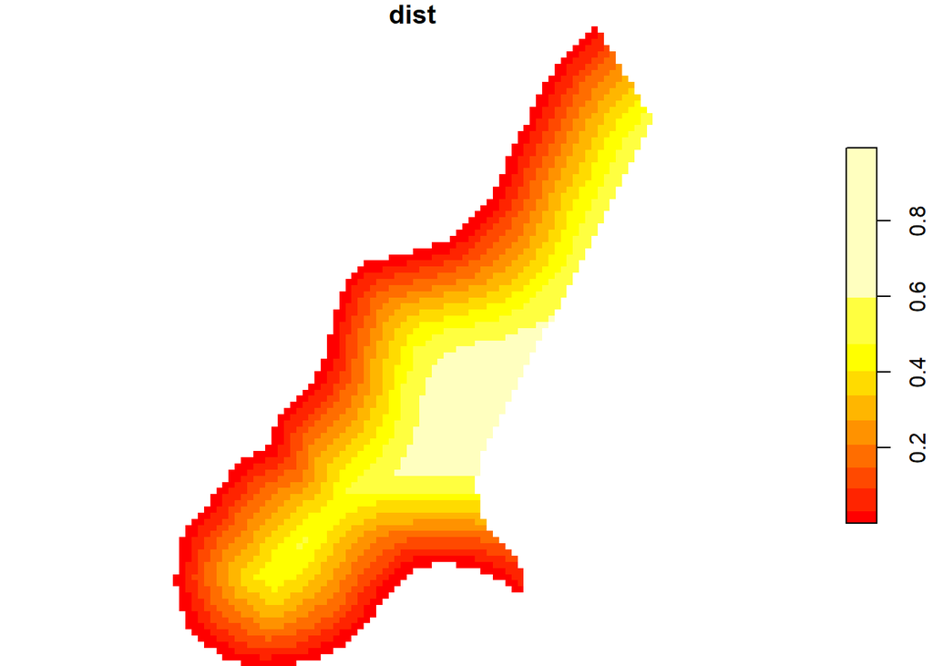

```r
plot(meuse.grid.stars[3], col=heat.colors(10))
```

## 1.6 Visualizing spatial data with the tmap package

In the previous section, we have used the function `spplot()` to create plots from data handled by the package **sp**, such as `SpatialPointsDataFrame` or `SpatialPixelsDataFrame`. While there are base `plot` methods for `sf` and `stars` objects as well (we have used some of them in the examples above, more examples can be found in the lecture material), we will use the package **tmap** (Tennekes 2022) for plotting objects of those classes throughout this exercise. **tmap** allows easy handling of `sf` and `stars` objects combined in one plot and offers a lot of utility for creating and styling maps and other visualizations of spatial data. The syntax for plotting is very simple and straightforward: the basic building blog of a plot is a `tm_shape` element, which defines the spatial data object (raster or vector) to be added to the map plus one or more layer elements, e.g., `tm_raster` or `tm_polygons`, which define how the object is to be plotted (and which aspects of it). Spatial data objects can be, e.g., an `sf` or `stars` object, but also objects from the packages **sp** or **raster**. All these elements are combined via the + operator. The example below creates a plot with one layer showing the “dist” attribute of `meuse.grid.stars` together with the polygon of the Meuse river.

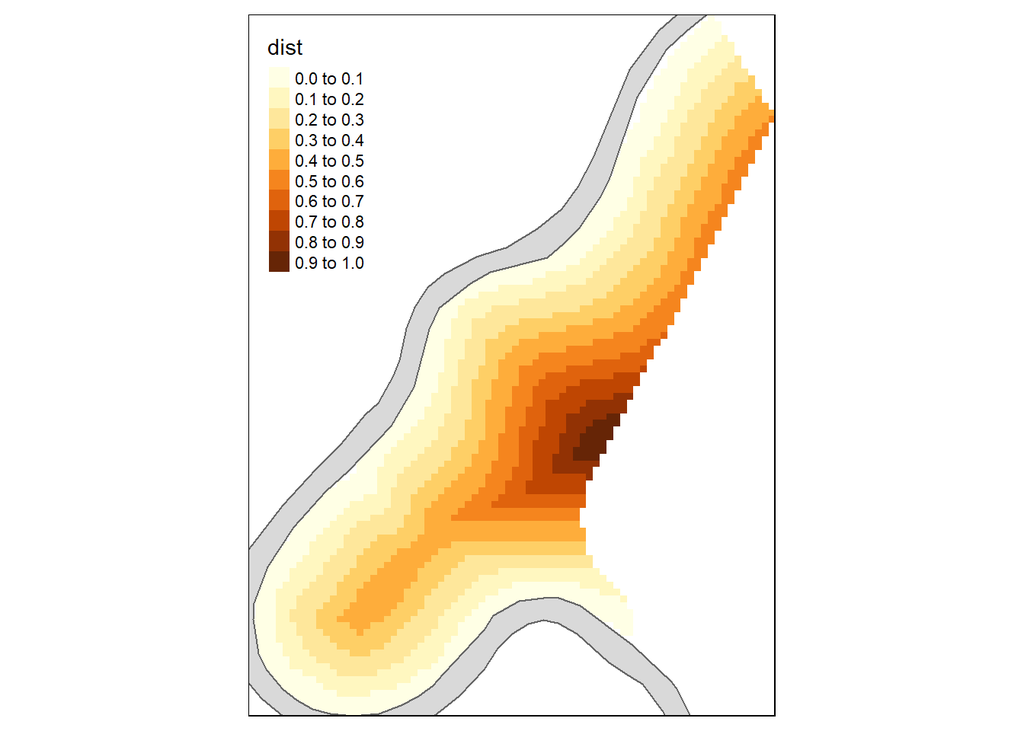

```r
library(tmap)
tm_shape(meuse.grid.stars)+tm_raster("dist",n=10)+tm_shape(meuse.riv.sf)+tm_polygons() #plots the `dist` attribute of the spatial data object `meuse.grid.stars` and the polygon of the Meuse river contained in spatial data object `meuse.riv.sf`
```

The functions for adding the layers like `tm_raster()` or `tm_polygons()` allow for several arguments further specifying how the layers should be visualized. In the code above we only specified that the raster layer should show the “dist” attribute with a preferred number of 10 classes. Many other arguments can be set as well (see below for an example that adds the point data of the “meuse.sf” data set with symbols of a specific shape, size and color).

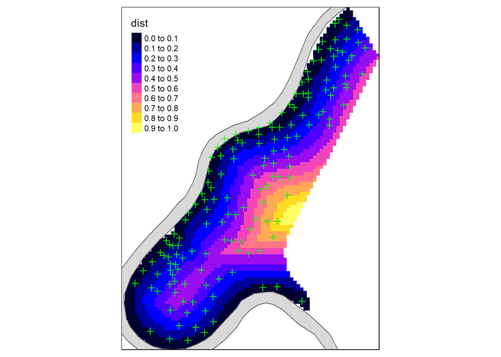

```r
bpy.palette <- bpy.colors() #define color palette for the following plots equal to the one used above by spplot()
tm_shape(meuse.grid.stars) +
  tm_raster("dist",n=10, palette = bpy.palette) +
  tm_shape(meuse.riv.sf) +
  tm_polygons() +
  tm_shape(meuse.sf) +
  tm_symbols(shape = 3,size = 0.2,col="green")
```

There are also other tmap elements, e.g., `tm_layout()`, which further specifies the overall map layout, or `tm_facets()`, which can be used to create small multiples in a map.

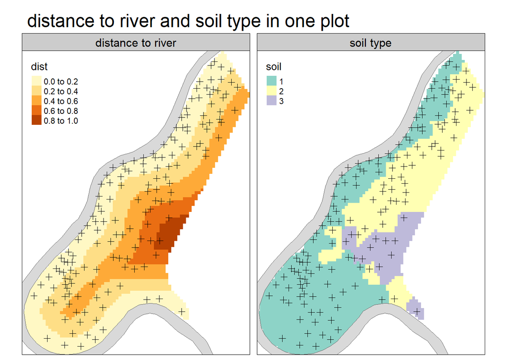

```r
tm_shape(meuse.grid.stars) +
  tm_raster(c("dist","soil")) +
  tm_shape(meuse.riv.sf)+ tm_polygons() +
  tm_shape(meuse) + tm_symbols(shape = 3,size = 0.2,col="black") +
  tm_facets() +
  tm_layout(legend.outside.size = 0.15, main.title = "distance to river and soil type in one plot", panel.labels = c("distance to river","soil type"))
```

**tmap** can be used not only for plotting static maps, but also for visualizing spatial data in an interactive viewer. Changing the mode to “view” will cause all visualizations to be shown in an interactive leaflet map including selectable background layers as well as zoom and pan functionality. The following code shows an example (note that after creating the interactive map, we switch back to the mode “plot” for creating static maps in the following sections).

```r
tmap_mode("view")
```

```
tmap mode set to interactive viewing
```

```r
tm_shape(meuse.grid.stars) +
  tm_raster("dist",n=10) +
  tm_shape(meuse.riv)+tm_polygons()
```

[interactive chart not shown]

```r
tmap_mode("plot")
```

```
tmap mode set to plotting
```

For more information on the use of **tmap** please refer to the [get started!](https://cran.r-project.org/web/packages/tmap/vignettes/tmap-getstarted.html#interactive-maps) vignette.

## 1.7 sp vs. sf & stars

Whether you prefer to use **sp** or **sf** and **stars**, is up to you. As mentioned above **sf** and **stars** are intended to replace **sp** in the long term. For now, we will always present the code for both alternatives when analyzing spatial data. You can switch between them by selecting the corresponding tabs in the code sections. You will notice that for the most part there are only minor (if any) differences between both alternatives. Most of the functions we will be using can handle objects from **sp**, **sf** and **stars** identically. Main differences occur when plotting the data (`spplot` for **sp**, functions from **tmap** for **sf** & **stars**).

# 2 Geostatistics

The following practical exercises cover the use of geostatistical applications in environmental research. They give an introduction to exploratory data analysis, sample variogram calculation and variogram modelling and several spatial interpolation techniques. Interpolation methods described and applied are inverse distance interpolation, trend surface fitting, thiessen polygons, ordinary (block) kriging, stratified (block) kriging and indicator (block) kriging.

The **gstat** R package (Pebesma and Graeler 2022) is used for all geostatistical calculations. See Pebesma (2004) for more info.

## 2.1 Simple interpolation algorithms

### 2.1.1 Trend surface analysis

Trend surface interpolation is multiple linear regression with polynomials of coordinates as independent, predictor variables. Although we could use `lm` to fit these models and predict them, it would require scaling of coordinates prior to prediction in most cases because higher powers of large coordinate values result in large numerical errors. The `krige` function in library `gstat` scales coordinates and computes trend surface up to order 3 (argument `degree`), using scaled coordinates.

**sp**

```r
meuse.grid$tr1 = krige(log(zinc) ~ 1, meuse, meuse.grid, degree = 1)$var1.pred
```

```
[ordinary or weighted least squares prediction]
```

```r
meuse.grid$tr2 = krige(log(zinc) ~ 1, meuse, meuse.grid, degree = 2)$var1.pred
```

```
[ordinary or weighted least squares prediction]
```

```r
meuse.grid$tr3 = krige(log(zinc) ~ 1, meuse, meuse.grid, degree = 3)$var1.pred
```

```
[ordinary or weighted least squares prediction]
```

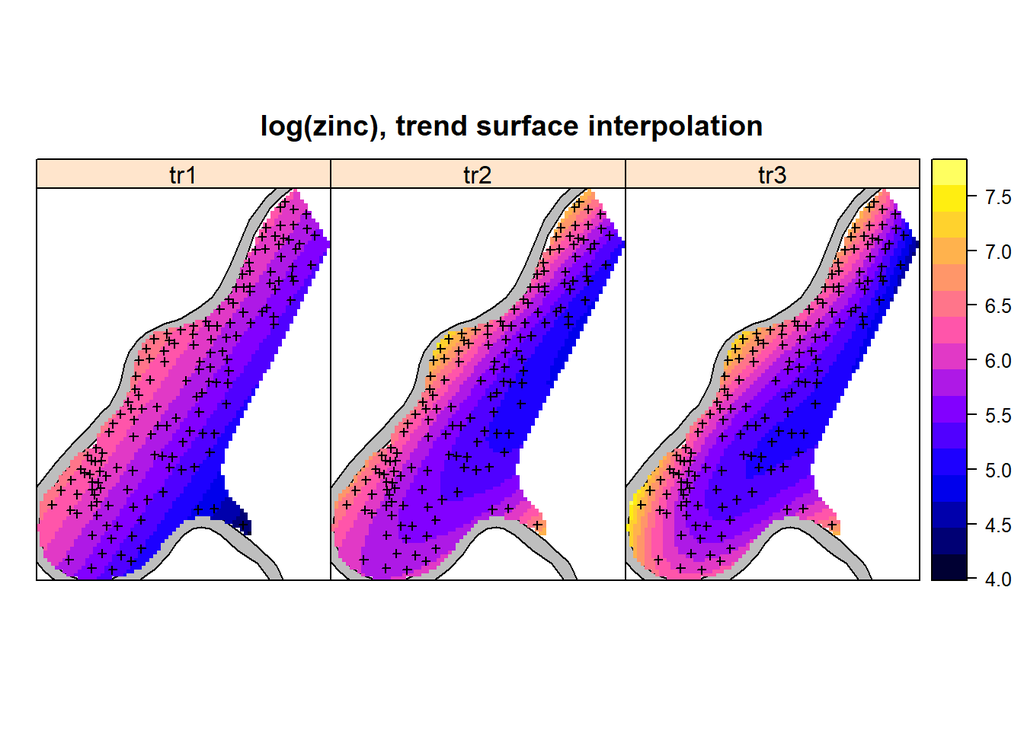

```r
spplot(meuse.grid, c("tr1", "tr2", "tr3"), sp.layout = meuse.lt, main = "log(zinc), trend surface interpolation")
```

**sf/stars**

```r
meuse.grid.stars$tr1 = krige(log(zinc) ~ 1, meuse.sf, meuse.grid.stars, degree = 1)$var1.pred
```

```
[ordinary or weighted least squares prediction]
```

```r
meuse.grid.stars$tr2 = krige(log(zinc) ~ 1, meuse.sf, meuse.grid.stars, degree = 2)$var1.pred
```

```
[ordinary or weighted least squares prediction]
```

```r
meuse.grid.stars$tr3 = krige(log(zinc) ~ 1, meuse.sf, meuse.grid.stars, degree = 3)$var1.pred
```

```
[ordinary or weighted least squares prediction]
```

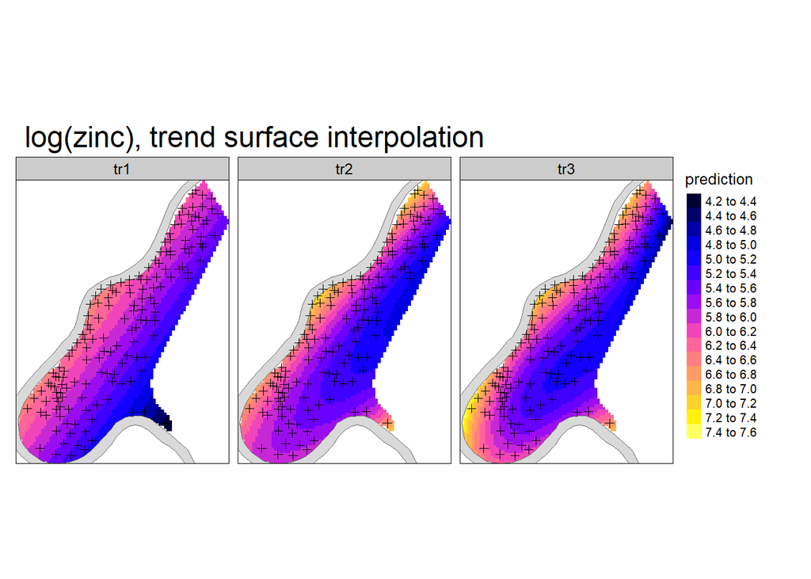

```r
tm_shape(meuse.grid.stars) +
  tm_raster(c("tr1","tr2","tr3"),n=20,title = "prediction", palette = bpy.palette) +
  tm_shape(meuse.riv.sf)+tm_polygons() +
  tm_shape(meuse)+tm_symbols(shape = 3,size = 0.2,col="black") +
  tm_facets(free.scales = FALSE) +
  tm_layout(legend.outside.size = 0.15, main.title = "log(zinc), trend surface interpolation", panel.labels = c("tr1","tr2","tr3"))
```

**Note**

Function `surf.ls` from library `spatial` fits trends up to order 6 with scaled coordinates.

Here is another example of the use of the `...` argument in function definitions. As you can see, `?krige` does not provide help on argument `degree`. However, it tells that any remaining arguments (`...`) are passed to function `gstat`, so look for argument `degree` on `?gstat` to see information on this argument.

In the example above, we have fitted trends up to order 3. The higher the order, the more exactly the surface can be fitted to the data. However…

#### *Exercise 2*

**Exercise 2**

*The danger of extreme extrapolation values is likely to occur*

1. for low trend orders
2. for high trend orders
3. for none of these models

*Briefly explain why this is the case.*

**Solution**

The correct answer is b). If you plot polynomials in one dimension, you can easily see that function values are more extreme for higher trend orders.

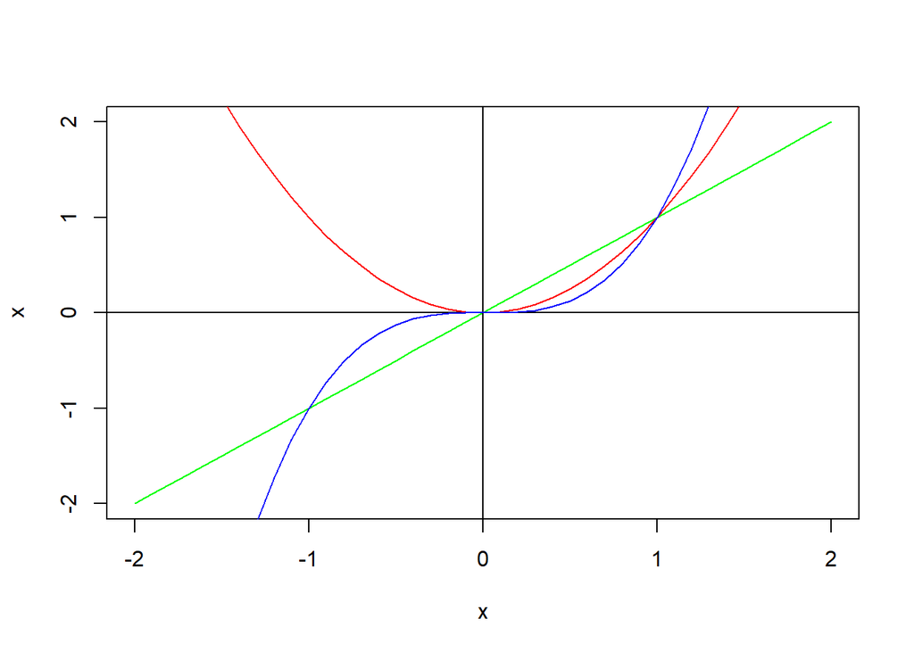

```r
x = seq(-2, 2, 0.1)
plot(x, x, type = "l", ylim = c(-2, 2), col = "green")  # 1. Ordnung (Gerade)
abline(v = 0, h = 0)
lines(x, x^2, col = "red")  # 2. Ordnung (Parabel)
lines(x, x^3, col = "blue")  # 3. Ordnung
```

Local trends, i.e. trends in a local neighbourhood may also be fitted:

**sp**

```r
m = krige(log(zinc) ~ 1, meuse, meuse.grid, degree=1, nmax = 10)
```

```
[ordinary or weighted least squares prediction]
```

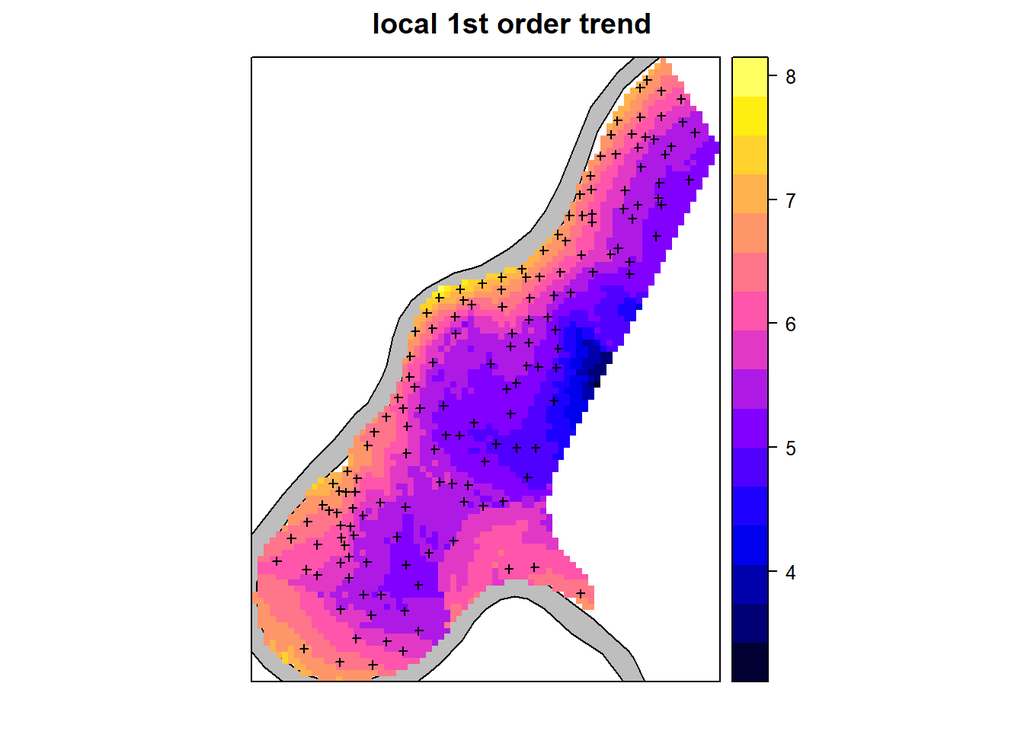

```r
spplot(m, "var1.pred", sp.layout = meuse.lt, main = "local 1st order trend")
```

**sf/stars**

```r
m = krige(log(zinc) ~ 1, meuse.sf, meuse.grid.stars, degree=1, nmax = 10)
```

```
[ordinary or weighted least squares prediction]
```

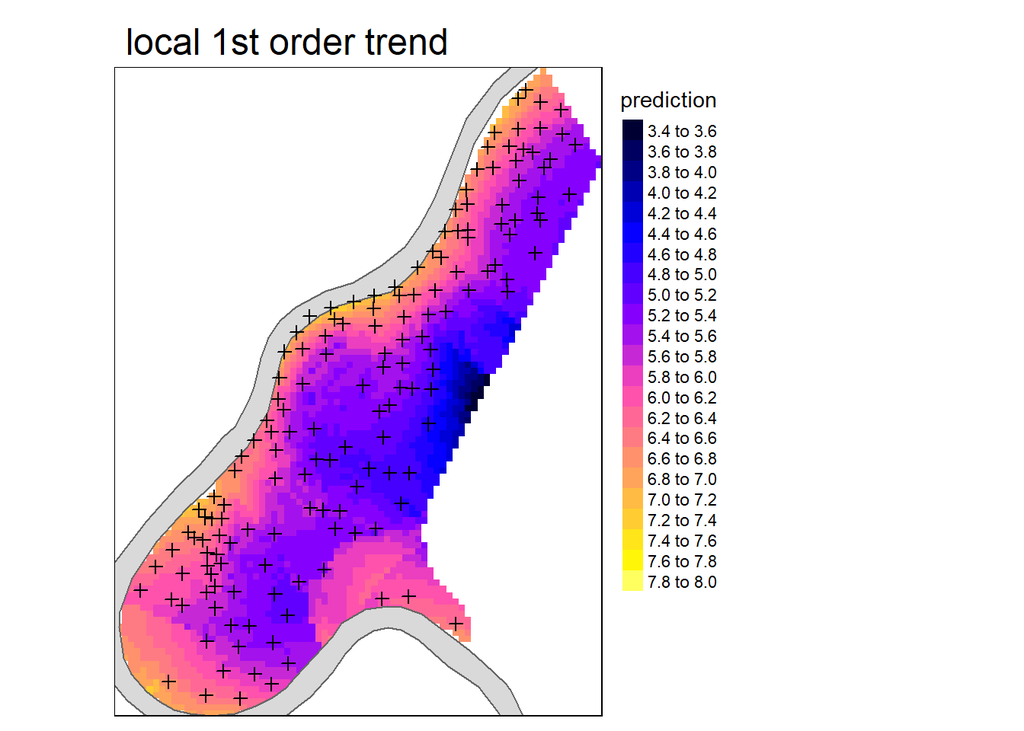

```r
tm_shape(m) +
  tm_raster("var1.pred", n=20, title = "prediction", palette = bpy.palette) +
  tm_shape(meuse.riv.sf)+tm_polygons() +
  tm_shape(meuse)+tm_symbols(shape = 3,size = 0.2,col="black") +
  tm_layout(main.title = "local 1st order trend", legend.outside = TRUE)
```

### 2.1.2 Inverse distance interpolation

Inverse distance interpolation calculates a weighted average of points in the (by default global) neighbourhood, using weights inverse proportional to the distance of data locations to the prediction location raised to the power $p$. This power is by default 2, but can of course be adapted:

**sp**

```r
lzn.tp = idw(log(zinc) ~ 1, meuse, meuse.grid)
```

```
[inverse distance weighted interpolation]
```

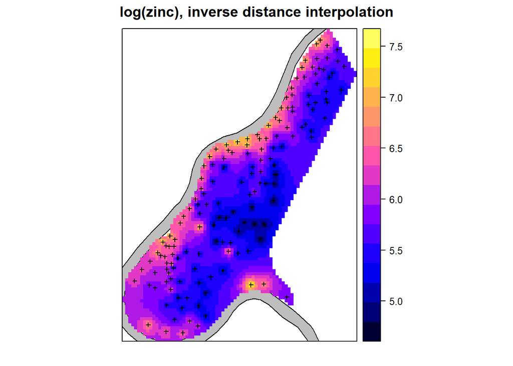

```r
spplot(lzn.tp, "var1.pred", sp.layout = meuse.lt, main = "log(zinc), inverse distance interpolation")
```

```r
meuse.grid$idp0.5 = idw(log(zinc) ~ 1, meuse, meuse.grid, idp = 0.5)$var1.pred
```

```
[inverse distance weighted interpolation]
```

```r
meuse.grid$idp02 = idw(log(zinc) ~ 1, meuse, meuse.grid, idp = 2)$var1.pred
```

```
[inverse distance weighted interpolation]
```

```r
meuse.grid$idp05 = idw(log(zinc) ~ 1, meuse, meuse.grid, idp = 5)$var1.pred
```

```
[inverse distance weighted interpolation]
```

```r
meuse.grid$idp10 = idw(log(zinc) ~ 1, meuse, meuse.grid, idp = 10)$var1.pred
```

```
[inverse distance weighted interpolation]
```

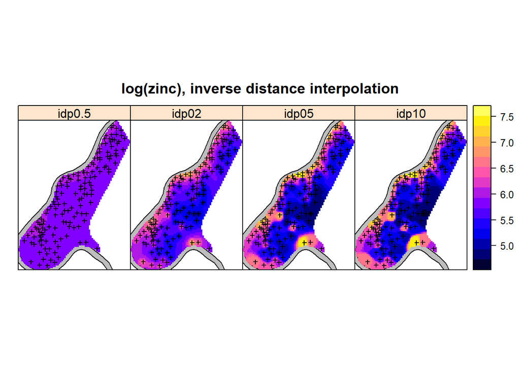

```r
spplot(meuse.grid, c("idp0.5", "idp02", "idp05", "idp10"), sp.layout = meuse.lt,
    main = "log(zinc), inverse distance interpolation")
```

**sf/stars**

```r
lzn.tp = idw(log(zinc) ~ 1, meuse.sf, meuse.grid.stars)
```

```
[inverse distance weighted interpolation]
```

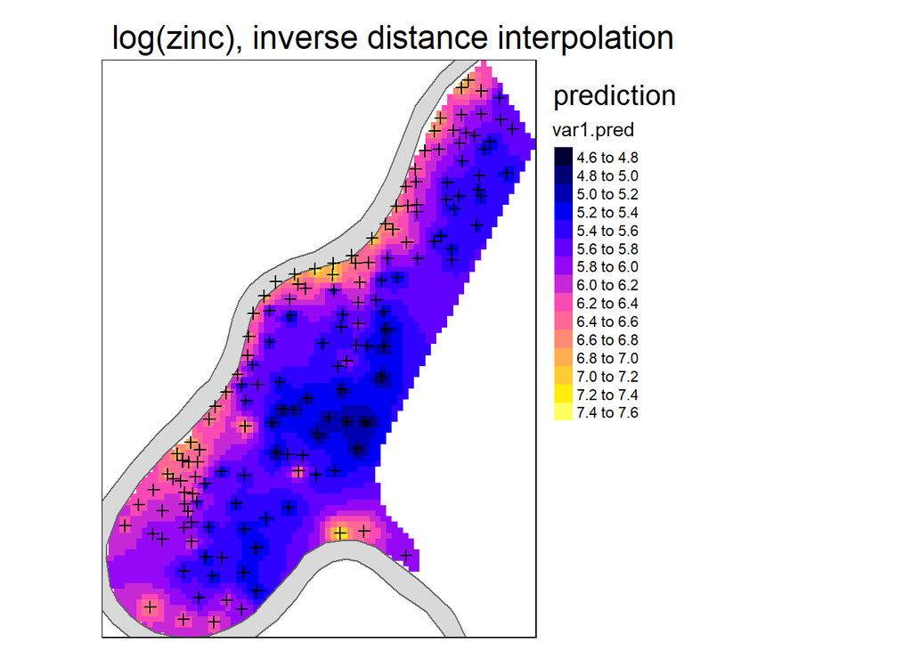

```r
tm_shape(lzn.tp)+tm_raster("var1.pred", palette = bpy.palette, n=10) +
  tm_shape(meuse.riv.sf) +
  tm_polygons() +
  tm_shape(meuse) +
  tm_symbols(shape = 3,size = 0.2,col="black") +
  tm_layout(main.title = "log(zinc), inverse distance interpolation", legend.outside = TRUE, title = "prediction" )
```

```r
meuse.grid.stars$idp0.5 = idw(log(zinc) ~ 1, meuse, meuse.grid.stars, idp = 0.5)$var1.pred
```

```
[inverse distance weighted interpolation]
```

```r
meuse.grid.stars$idp02 = idw(log(zinc) ~ 1, meuse, meuse.grid.stars, idp = 2)$var1.pred
```

```
[inverse distance weighted interpolation]
```

```r
meuse.grid.stars$idp05 = idw(log(zinc) ~ 1, meuse, meuse.grid.stars, idp = 5)$var1.pred
```

```
[inverse distance weighted interpolation]
```

```r
meuse.grid.stars$idp10 = idw(log(zinc) ~ 1, meuse, meuse.grid.stars, idp = 10)$var1.pred
```

```
[inverse distance weighted interpolation]
```

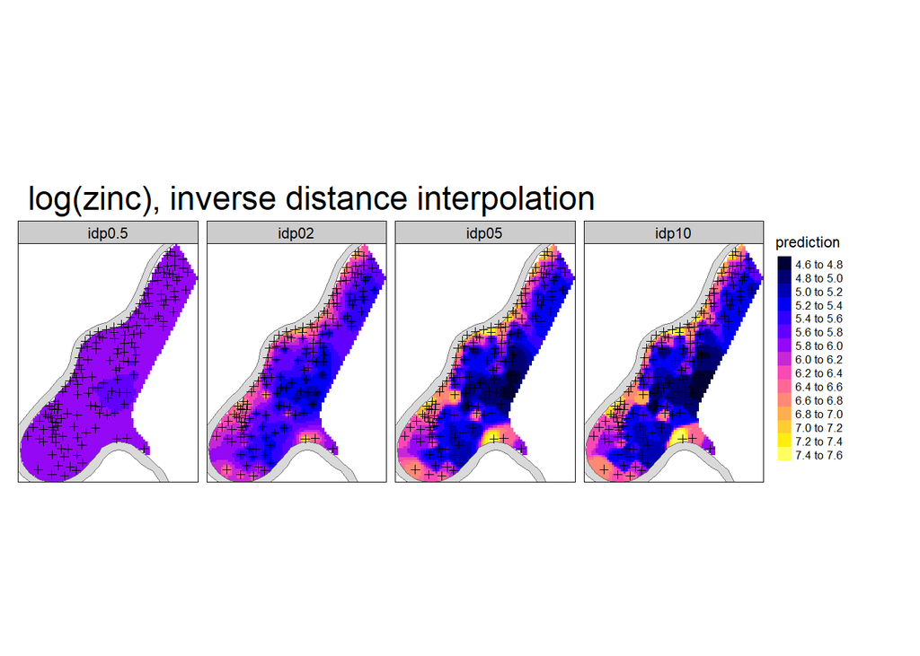

```r
tm_shape(meuse.grid.stars) +
  tm_raster(c("idp0.5","idp02","idp05","idp10"),n=10, title = "prediction", palette = bpy.palette) +
  tm_shape(meuse.riv.sf) +
  tm_polygons() +
  tm_shape(meuse) +
  tm_symbols(shape = 3,size = 0.2,col="black") +
  tm_facets(nrow=1,free.scales = FALSE) +
  tm_layout(main.title = "log(zinc), inverse distance interpolation",legend.outside.size = 0.15,panel.labels = c("idp0.5","idp02","idp05","idp10"))
```

#### *Exercise 3*

**Exercise 3**

*With a larger inverse distance power (`idp`), the weight of the nearest data point*

1. becomes larger
2. becomes smaller
3. does not change

*explain in words why this is the case.*

**Solution**

The correct answer is a). With a higher inverse distance power the weight of a data point decreases more quickly with increasing distance.
$$\lambda_i = \frac{|s_i-s_0|^{-p}}{\sum_{i=1}^n |s_i-s_0|^{-p}}$$

### 2.1.3 Nearest Neighbor / Tiessen (or Voronoi) Polygons

Nearest neighbor interpolation on a regular grid (creating Thiessen Polygons) is simply obtained by using e.g. inverse distance interpolation and a neighbourhood size of one (`nmax = 1`). :

**sp**

```r
lzn.tp = krige(log(zinc) ~ 1, meuse, meuse.grid, nmax = 1)
```

```
[inverse distance weighted interpolation]
```

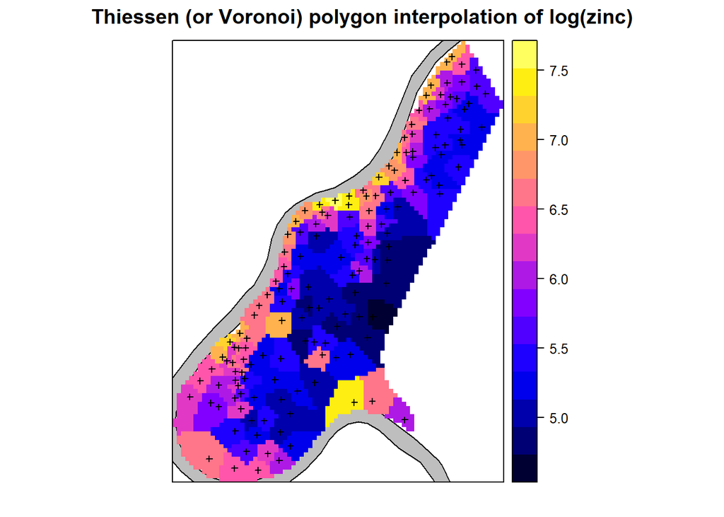

```r
spplot(lzn.tp, "var1.pred", sp.layout = meuse.lt, main = "Thiessen (or Voronoi) polygon interpolation of log(zinc)")
```

**sf/stars**

```r
lzn.tp = krige(log(zinc) ~ 1, meuse.sf, meuse.grid.stars, nmax = 1)
```

```
[inverse distance weighted interpolation]
```

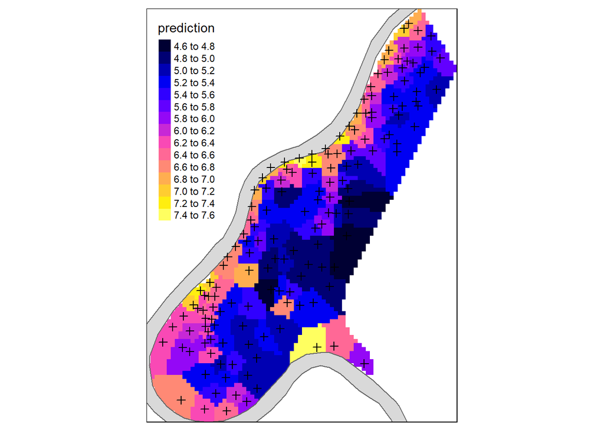

```r
tm_shape(lzn.tp) +
  tm_raster("var1.pred",n=10,title="prediction", palette = bpy.palette) +
  tm_shape(meuse.riv.sf)+tm_polygons() +
  tm_shape(meuse) +
  tm_symbols(shape = 3,size = 0.2,col="black")
```